# Did Jean-Auguste-Dominique Ingres use less saturated values than Jacques Louis David in his historical paintings?

# Artist prediction based on Saturation and Hue values

From the above statistical tests, we have deduced that both the saturation and hue values used by Ingres and David are statistically different. Therefore, we will explore the possibility of using the saturation and hue values to predict which artist used the colour.

Let’s first explore the relationship between hue and saturation for both artists. First, let’s create a dataframe.

```r
dav_scatter <- as.data.frame(dav_sat_vector_random)
dav_scatter$Artist <- 'DAVID, Jacques-Louis'
dav_scatter <- cbind(dav_hue_vector_random, dav_scatter)
colnames(dav_scatter) <- c("Hue","Saturation", "Artist")

ing_scatter <- as.data.frame(ing_sat_vector_random)
ing_scatter$Artist <- 'INGRES, Jean-Auguste-Dominique'
ing_scatter <- cbind(ing_hue_vector_random, ing_scatter)
colnames(ing_scatter) <- c("Hue","Saturation", "Artist")

combined_scatter <- rbind(dav_scatter, ing_scatter)
```

```r
combined_scatter_random <- combined_scatter[sample(nrow(combined_scatter), 750000, replace = FALSE, prob = NULL),]
nrow(combined_scatter_random[combined_scatter_random$Artist == 'DAVID, Jacques-Louis',])
nrow(combined_scatter_random[combined_scatter_random$Artist == 'INGRES, Jean-Auguste-Dominique',])
```

[output not shown]

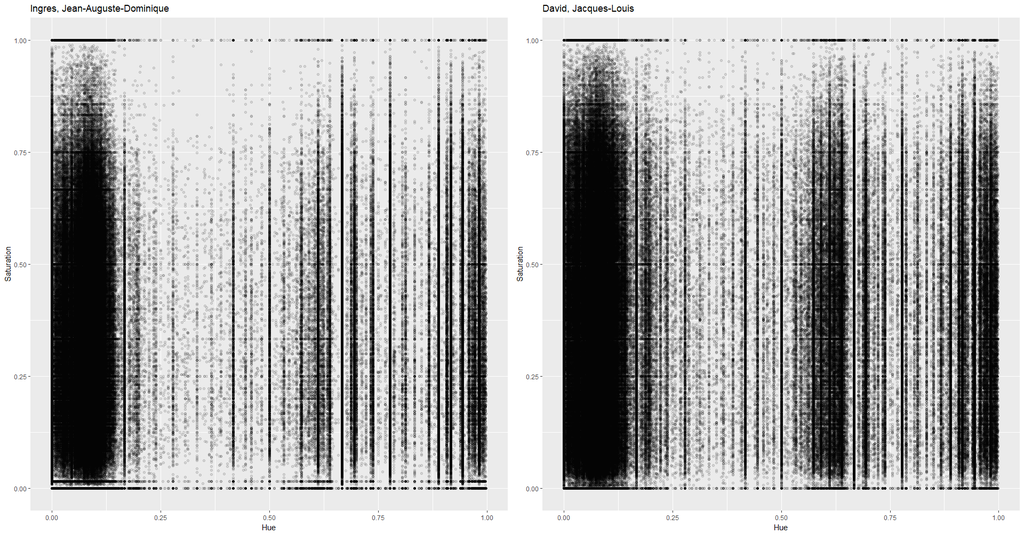

```r
dav_sc <- ggplot(combined_scatter_random[combined_scatter_random$Artist == 'DAVID, Jacques-Louis',], aes(Hue, Saturation)) + geom_point(alpha = 1/10) + labs(title = "David, Jacques-Louis")

ing_sc <- ggplot(combined_scatter_random[combined_scatter_random$Artist == 'INGRES, Jean-Auguste-Dominique',], aes(Hue, Saturation)) + geom_point(alpha = 1/10) + labs(title = "Ingres, Jean-Auguste-Dominique")

grid.arrange(ing_sc,dav_sc, ncol=2)
```

Let’s see how they look plotted together

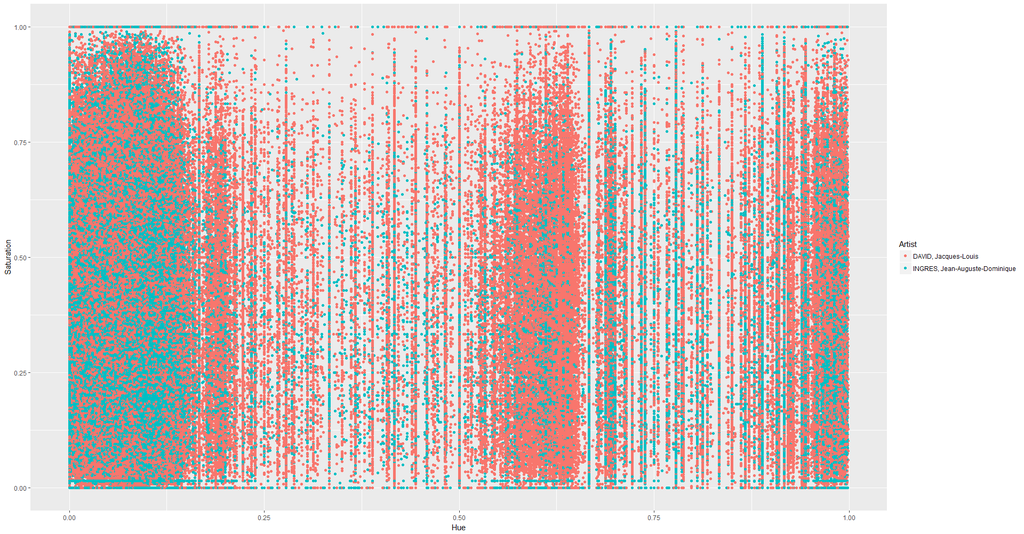

```r
ggplot(combined_scatter_random, aes(Hue, Saturation)) + geom_point(aes(colour = Artist))
```

# Prediction preparation

Split into train and test data. 60% train, 40% test.

```r
samp <- sample(nrow(combined_scatter_random), 0.6 * nrow(combined_scatter_random))
train <- combined_scatter_random[samp, ]
test <- combined_scatter_random[-samp, ]
```

```r
model <- randomForest(as.factor(Artist) ~ Hue + Saturation, data = train, importance = TRUE, ntree = 10)
```

From the importance plot, the saturation has greater effect on accuracy were it to be removed, compared to Hue.

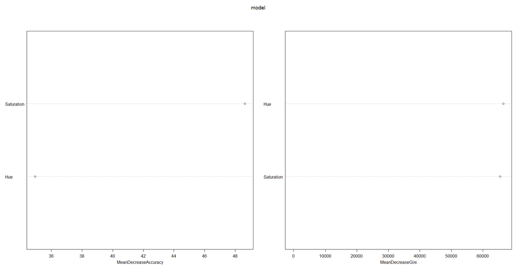

```r
varImpPlot(model)
```

# Prediction!

```r
Prediction <- predict(model, test)
table(Prediction, test$Artist)

Prediction                       DAVID, Jacques-Louis INGRES, Jean-Auguste-Dominique
  DAVID, Jacques-Louis                          83324                          48340
  INGRES, Jean-Auguste-Dominique                66494                         101842
```

Random Forest predicts with 62% accurracy.